# Manuscript figures

Regina H. Reynolds

UCL

```r
library(cowplot) # For alignment of plots using axes
library(DT) # R interface to the JavaScript library DataTables
library(ggpubr) # For arranging plots in one panel
library(here) # For file path construction
library(readxl) # For loading excel workbooks
library(openxlsx) # For writing to excel workbooks
library(tidyverse) # For data manipulation
library(stringr) # For string manipulation
library(qdapTools) # For list manipulation

# To use MarkerGene package, clone from: https://github.com/RHReynolds/MarkerGenes
path_to_ewce_pkg <- "/home/rreynolds/packages/EWCE/" # necessary due to issues with R versioning, see https://github.com/NathanSkene/EWCE
path_to_markergenes_pkg <- "/home/rreynolds/projects/MarkerGenes/"
devtools::load_all(path_to_ewce_pkg) # Function for querying specificity matrices
devtools::load_all(path_to_markergenes_pkg) # Function for querying specificity matrices

knitr::opts_chunk$set(echo = TRUE, warning = FALSE, message = FALSE)
```

# 1 Paths for saving files

```r
path_for_figures <- here::here("manuscript", "figures/")
path_for_tables <- here::here("manuscript", "tables/")
```

# 2 Plotting functions

```r
source(here::here("R", "plotting_functions.R"))

# Set base_size for plots
theme_base_size <- 10
theme_base_size_small <- 8
```

# 3 Regional association plots and tissue/cell-type specificity

## 3.1 Loading data

```r
# All coloc results
results <-
  readRDS(here::here("results", "coloc_summary.Rds"))

# GWAS and eQTL points to plot
plot_data <-
  setNames(
    vector(mode = "list", length = 4),
    c("psychencode", "eQTLGen", "gtex", "aibs")
  )

plot_data[[1]] <-
  readRDS(here::here("results", "psychencode", "RBD_psychencode_overlap.Rds")) %>%
  qdapTools::list_df2df() %>%
  dplyr::select(
    SNP,
    gene = gene_2,
    pvalue_gwas = p.value_1,
    pvalue_eqtl = p.value_2
  ) %>%
  dplyr::inner_join(
    results$robust %>%
      dplyr::filter(dataset == "psychencode") %>%
      dplyr::select(gene = gene_2, hgnc_symbol)
  ) %>%
  tidyr::gather(
    key = "Dataset",
    value = "p.value",
    -SNP, -gene, -hgnc_symbol
  ) %>%
  tidyr::separate(col = "SNP", into = c("chr", "pos")) %>%
  dplyr::mutate(
    pos_mb = as.numeric(pos) / 1000000,
    p.value = as.numeric(p.value),
    log_pval = -log10(p.value),
    hgnc_symbol = case_when(
      gene == "ENSG00000247775" ~ "SNCA-AS1",
      TRUE ~ hgnc_symbol
    )
  )

plot_data[[2]] <-
  readRDS(here::here("results", "eQTLGen", "RBD_eQTLGen_overlap.Rds")) %>%
  qdapTools::list_df2df() %>%
  dplyr::select(
    SNP,
    gene = gene_2,
    pvalue_gwas = p.value_1,
    pvalue_eqtl = p.value_2
  ) %>%
  dplyr::inner_join(
    results$robust %>%
      dplyr::filter(dataset == "eQTLGen") %>%
      dplyr::select(gene = gene_2, hgnc_symbol)) %>%
  tidyr::gather(
    key = "Dataset",
    value = "p.value",
    -SNP, -gene, -hgnc_symbol
  ) %>%
  tidyr::separate(col = "SNP", into = c("chr", "pos")) %>%
  dplyr::mutate(
    pos_mb = as.numeric(pos) / 1000000,
    p.value = as.numeric(p.value),
    log_pval = -log10(p.value)
  )


# Load necessary specificity matrices
load(str_c(path_to_markergenes_pkg, "specificity_matrices/AIBS2018_MTG.rda"))
genes <- c("MMRN1", "SNCA-AS1")

plot_data$gtex <-
  readRDS(str_c(path_to_markergenes_pkg, "specificity_df/GTEx_v8.Rds")) %>%
  dplyr::filter(Description %in% genes) %>%
  dplyr::arrange(Description, -specificity)

plot_data$aibs <-
  MarkerGenes::query_gene_ctd(
    genes = genes,
    ctd_AIBS2018,
    celltypeLevel = 1,
    median_included = F,
    genelistSpecies = "human",
    ctdSpecies = "human"
  )
```

## 3.2 Plot

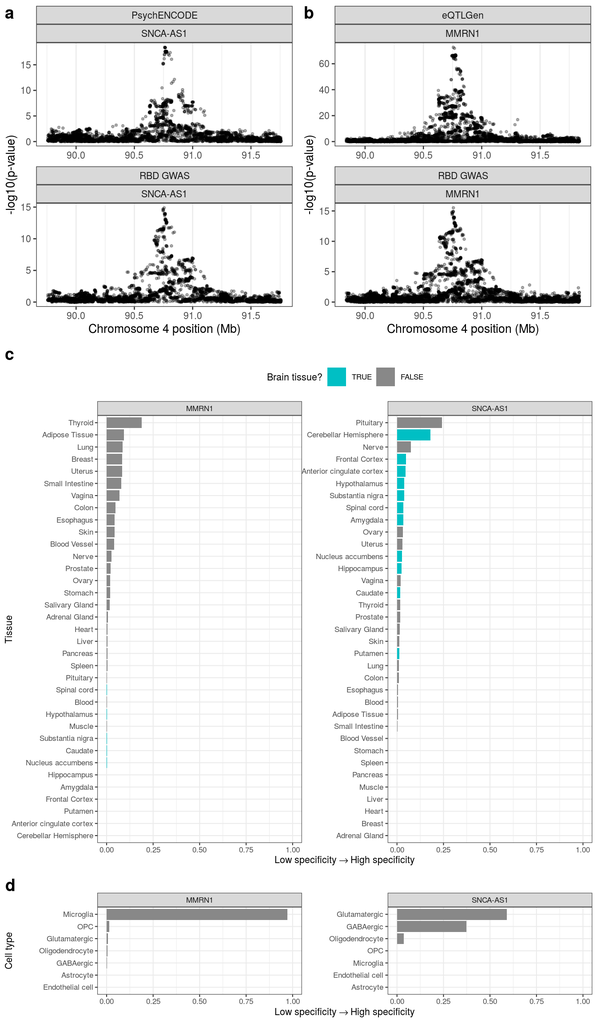

```r
fig_list <- vector(mode = "list", length = 4)

plot_tibble <-
  tibble(
    dataset = c("psychencode", "eQTLGen"),
    GWAS_label = rep("RBD GWAS", 2),
    dataset_label = c("PsychENCODE", "eQTLGen"),
    figure_label = letters[1:2]
  )

for (i in 1:nrow(plot_tibble)) {

  fig_list[[i]] <-
    plot_coloc_hits(
      coloc_hits =
        results$robust %>%
        dplyr::filter(
          dataset == plot_tibble$dataset[i],
          PP.H4.abf >= 0.75
        ) %>%
        dplyr::arrange(hgnc_symbol) %>%
        .[["gene_2"]],
      eQTL_GWAS_to_plot = plot_data[[i]],
      facet_labels = c(pvalue_gwas = plot_tibble$GWAS_label[i],
                       pvalue_eqtl = plot_tibble$dataset_label[i]),
      figure_labels = plot_tibble$figure_label[i],
      theme_base_size = theme_base_size
    )

}

fig_list[[3]] <-
  plot_gtex_specificity(
    specificity = plot_data$gtex,
    theme_base_size = theme_base_size_small
  )

fig_list[[4]] <-
  plot_aibs_specificity(
    specificity = plot_data$aibs,
    theme_base_size = theme_base_size_small
  )

fig <-
  ggarrange(
    ggarrange(
      plotlist = fig_list[1:2],
      align = "v",
      ncol = 2,
      nrow = 1,
      common.legend = TRUE
    ),
    ggarrange(
      plotlist = fig_list[3:4],
      nrow = 2,
      align = "v",
      labels = letters[3:4],
      heights = c(3.5,1)
    ),
    nrow = 2,
    heights = c(1,2)
  )

fig
```

### 3.2.1 Figure caption

**Regional association plots for eQTL and RBD GWAS colocalisations and tissue and cell-type specificity of *MMRN1* and *SNCA-AS1*.** Regional association plots for eQTL (upper pane) and RBD GWAS association signals (lower pane) in the regions surrounding **(a)** *SNCA-AS1* (PPH4 = 0.89) and **(b)** *MMRN1* (PPH4 = 0.86). eQTLs are derived from **(a)** PsychENCODE's analysis of adult brain tissue from 1387 individuals or **(b)** the eQTLGen meta-analysis of 31,684 blood samples from 37 cohorts. In **(a)** and **(b)**, the x-axis denotes chromosomal position in hg19, and the y-axis indicates association p-values on a -log<sub>10</sub> scale. Plot of *MMRN1* and *SNCA-AS1* specificity in **(c)** 35 human tissues (GTEx dataset) and **(d)** 7 broad categories of cell type derived from human middle temporal gryus (AIBS dataset). Specificity represents the proportion of a gene’s total expression attributable to one cell type/tissue, with a value of 0 meaning a gene is not expressed in that cell type/tissue and a value of 1 meaning that a gene is only expressed in that cell type/tissue. In **(c)** tissues are coloured by whether they belong to the brain. In **(c)** and **(d)**, tissues and cell types have been ordered by specificity from high to low.

## 3.3 Supplementary figure

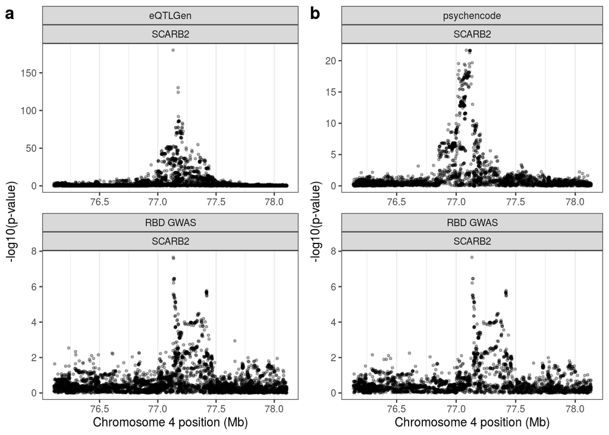

```r
fig_list <- vector(mode = "list", length = 2)

plot_tibble <-
  tibble(
    dataset = c("psychencode", "eQTLGen"),
    GWAS_label = rep("RBD GWAS", 2),
    dataset_label = c("psychencode", "eQTLGen"),
    figure_label = letters[2:1]
  )

for (i in 1:nrow(plot_tibble)) {

  fig_list[[i]] <-
    plot_coloc_hits(
      coloc_hits =
        results$robust %>%
        dplyr::filter(
          dataset == plot_tibble$dataset[i],
          hgnc_symbol == "SCARB2"
        ) %>%
        dplyr::arrange(hgnc_symbol) %>%
        .[["gene_2"]],
      eQTL_GWAS_to_plot = plot_data[[i]],
      facet_labels = c(pvalue_gwas = plot_tibble$GWAS_label[i],
                       pvalue_eqtl = plot_tibble$dataset_label[i]),
      figure_labels = plot_tibble$figure_label[i],
      theme_base_size = theme_base_size
    )

}

supp_fig <-
  ggarrange(
    plotlist = fig_list[2:1],
    align = "v",
    ncol = 2,
    nrow = 1,
    common.legend = TRUE
  )

supp_fig
```

## 3.4 Supplementary table: coloc

```r
supp_table_coloc <-
  setNames(
    vector(mode = "list", length = 2),
    c("ColumnDescriptions", "Results")
  )

supp_table_coloc[[2]] <-
  results %>%
  qdapTools::list_df2df(col1 = "prior_type") %>%
  dplyr::filter(prior_type == "robust", dataset %in% c("psychencode", "eQTLGen")) %>%
  dplyr::mutate(hgnc_symbol = case_when(
    gene_2 == "ENSG00000247775" ~ "SNCA-AS1",
    TRUE ~ hgnc_symbol
  )) %>%
  dplyr::select(
    dataset,
    ensembl_id = gene_2, hgnc_symbol,
    PP_H0 = PP.H0.abf, PP_H1 = PP.H1.abf,
    PP_H2 = PP.H2.abf, PP_H3 = PP.H3.abf, PP_H4 = PP.H4.abf,
    sum_PPH3_PPH4, ratio_PPH4_PPH3
  ) %>%
  dplyr::arrange(dataset, ensembl_id)

supp_table_coloc[[1]] <-
  tibble(
    `Column name` = colnames(supp_table_coloc[[2]]),
    Description = c(
      "eQTL dataset name",
      "Gene ensembl ID",
      "Gene HGNC symbol",
      "Posterior probability of hypothesis 0: No association with either trait",
      "Posterior probability of hypothesis 1: Association with trait 1, not with trait 2",
      "Posterior probability of hypothesis 2: Association with trait 2, not with trait 1",
      "Posterior probability of hypothesis 3: Association with trait 1 and trait 2, two independent SNPs",
      "Posterior probability of hypothesis 3: Association with trait 1 and trait 2, one shared SNP",
      "Sum of PP_H3 and PP_H4",
      "Ratio of PP_H4 to PP_H3"
    )
  )
```

### 3.4.1 Table caption

**Results of colocalisation analysis using the RBD GWAS and eQTLs derived from eQTLGen and PsychENCODE.**

## 3.5 Supplementary table: tissue/cell-type specificity

```r
supp_table_specificity <- setNames(
  vector(mode = "list", length = 2),
  c("ColumnDescriptions", "Results")
)

supp_table_specificity[[2]] <-
  plot_data$gtex %>%
  dplyr::mutate(Study = "GTEx") %>%
  dplyr::select(Study, Gene = Description, CellType_Tissue = Organ, Specificity = specificity, Mean_Expression = mean_expr) %>%
  dplyr::bind_rows(plot_data$aibs %>%
    dplyr::mutate(Study = Study %>%
      str_replace(., "ctd_", "")) %>%
    dplyr::select(Study, Gene, CellType_Tissue = CellType, Specificity, Mean_Expression))

supp_table_specificity[[1]] <-
  tibble(
    `Column name` = colnames(supp_table_specificity[[2]]),
    Description = c(
      "Dataset from which specificity values were derived",
      "Gene HGNC symbol",
      "Cell type or tissue name",
      "Proportion of a gene's total expression attributable to one cell type or tissue",
      "Mean expression across a cell type or tissue"
    )
  )
```

### 3.5.1 Table caption

**Specificity values of *MMRN1* and *SNCA-AS1* in GTEx and AIBS datasets.**

## 3.6 Export files

```r
ggsave("figure_coloc_specificity.png", fig,
  device = "png",
  path = path_for_figures,
  width = 180,
  height = 270,
  units = "mm",
  dpi = 300,
  limitsize = TRUE
)

ggsave("figure_coloc_specificity.pdf", fig,
  device = "pdf",
  path = path_for_figures,
  width = 180,
  height = 270,
  units = "mm",
  dpi = 300,
  limitsize = TRUE
)

ggsave("supp_figure_coloc.png", supp_fig,
  device = "png",
  path = path_for_figures,
  width = 180,
  height = 120,
  units = "mm",
  dpi = 300,
  limitsize = TRUE
)

openxlsx::write.xlsx(supp_table_coloc,
  file = str_c(path_for_tables, "supp_table_coloc.xlsx"),
  row.names = FALSE,
  headerStyle = openxlsx::createStyle(textDecoration = "BOLD"),
  firstRow = TRUE,
  append = TRUE
)

openxlsx::write.xlsx(supp_table_specificity,
  file = str_c(path_for_tables, "supp_table_specificity.xlsx"),
  row.names = FALSE,
  headerStyle = openxlsx::createStyle(textDecoration = "BOLD"),
  firstRow = TRUE,
  append = TRUE
)
```